# Forking a GitHub Repository

## Another Recap: Git vs. GitHub

- You don't need GitHub to use Git
- Git = Local (on your computer); GitHub = Remote (on the web)
- GitHub allows you to:
1. Share your repositories with others
2. Access other users' repositories
3. Store remote copies of your repositories (on GitHub's server) in case something happens to your local copies (on your computer)

## Another Recap: Creating a GitHub Repository

- Two methods of creating a GitHub repository:
1. Start a repository from scratch
2. "Fork" another user's repository
- Last lecture dealt with the first method
- This lecture will walk you through the second method
- *NOTE: A repository is often referred to as a "repo"*

## Fork a Another User's Repository

- The second method of creating a respository is to make a copy of someone else's
- This process is called "forking" and is an important aspect of open-source software development
- Begin by navigating to the desired repository on the GitHub website and click the "Fork" button shown below

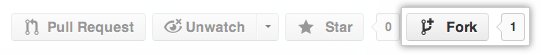

https://help.github.com/articles/fork-a-repo

## Clone the Repo

- You now have a copy of the desired respository on your GitHub account
- Need to make a local copy of the repo on your computer
- This process is called "cloning" and can be done using the following command (from either Git Bash or Terminal, depending on whether you are using Windows or Mac, respectively):

```
$ git clone https://github.com/your-user-name-goes-here/repo-name-here.git
```

- NOTE: This will clone the repository into your current directory. You can always tell what directory you are in by typing `pwd` (for "print working directory") from the command line.

## What Else?

- If you make changes to your local copy of the repo, you'll probably want to push your changes to GitHub at some point
- You also may be interested in staying current with any changes made to the original repository from which you forked your copy
- We will cover some more Git and GitHub basics in coming lectures, but in the meantime, here are some great resources:
- https://help.github.com/articles/fork-a-repo
- http://git-scm.com/book/en/Git-Basics-Getting-a-Git-Repository